# NYC FoodHub Data Analysis

### Context

The number of restaurants in New York is increasing day by day. Lots of students and busy professionals rely on those restaurants due to their hectic lifestyles. Online food delivery service is a great option for them. It provides them with good food from their favorite restaurants. A food aggregator company FoodHub offers access to multiple restaurants through a single smartphone app.

The app allows the restaurants to receive a direct online order from a customer. The app assigns a delivery person from the company to pick up the order after it is confirmed by the restaurant. The delivery person then uses the map to reach the restaurant and waits for the food package. Once the food package is handed over to the delivery person, he/she confirms the pick-up in the app and travels to the customer's location to deliver the food. The delivery person confirms the drop-off in the app after delivering the food package to the customer. The customer can rate the order in the app. The food aggregator earns money by collecting a fixed margin of the delivery order from the restaurants.

### Objective

The food aggregator company has stored the data of the different orders made by the registered customers in their online portal. They want to analyze the data to get a fair idea about the demand of different restaurants which will help them in enhancing their customer experience. Suppose you are hired as a Data Scientist in this company and the Data Science team has shared some of the key questions that need to be answered. Perform the data analysis to find answers to these questions that will help the company to improve the business.

### Data Description

The data contains the different data related to a food order. The detailed data dictionary is given below.

### Data Dictionary

- order_id: Unique ID of the order
- customer_id: ID of the customer who ordered the food
- restaurant_name: Name of the restaurant
- cuisine_type: Cuisine ordered by the customer
- cost_of_the_order: Cost of the order
- day_of_the_week: Indicates whether the order is placed on a weekday or weekend (The weekday is from Monday to Friday and the weekend is Saturday and Sunday)
- rating: Rating given by the customer out of 5
- food_preparation_time: Time (in minutes) taken by the restaurant to prepare the food. This is calculated by taking the difference between the timestamps of the restaurant's order confirmation and the delivery person's pick-up confirmation.
- delivery_time: Time (in minutes) taken by the delivery person to deliver the food package. This is calculated by taking the difference between the timestamps of the delivery person's pick-up confirmation and drop-off information

### Let us start by importing the required libraries

```python
# Installing the libraries with the specified version.
!pip install -q numpy
!pip install -q pandas
!pip install -q matplotlib
!pip install -q seaborn -q --user
!pip install -q scikit-learn
```

**Note**: *After running the above cell, kindly restart the notebook kernel and run all cells sequentially from the start again.*

```python
# Import libraries for data manipulation
import numpy as np
import pandas as pd

# Import libraries for data visualization and ML
import matplotlib.pyplot as plt
import seaborn as sns
import sklearn as sk

# Ignore all warnings
import warnings
warnings.filterwarnings('ignore')
```

### 1. Understanding the structure of the data

```python
# Read the data
path = "C:/Users/mohammc/Desktop/Data Science Projects/foodhub_order.csv"
df = pd.read_csv(path) ## Fill the blank to read the data
```

```python
# Returns the first 5 rows
df.head()
```

|  | order_id | customer_id | restaurant_name | cuisine_type | cost_of_the_order | day_of_the_week | rating | food_preparation_time | delivery_time |
| --- | --- | --- | --- | --- | --- | --- | --- | --- | --- |
| 0 | 1477147 | 337525 | Hangawi | Korean | 30.75 | Weekend | Not given | 25 | 20 |
| 1 | 1477685 | 358141 | Blue Ribbon Sushi Izakaya | Japanese | 12.08 | Weekend | Not given | 25 | 23 |
| 2 | 1477070 | 66393 | Cafe Habana | Mexican | 12.23 | Weekday | 5 | 23 | 28 |
| 3 | 1477334 | 106968 | Blue Ribbon Fried Chicken | American | 29.20 | Weekend | 3 | 25 | 15 |
| 4 | 1478249 | 76942 | Dirty Bird to Go | American | 11.59 | Weekday | 4 | 25 | 24 |

```python
# Display the last 5 rows
df.tail()
```

|  | order_id | customer_id | restaurant_name | cuisine_type | cost_of_the_order | day_of_the_week | rating | food_preparation_time | delivery_time |
| --- | --- | --- | --- | --- | --- | --- | --- | --- | --- |
| 1893 | 1476701 | 292602 | Chipotle Mexican Grill $1.99 Delivery | Mexican | 22.31 | Weekend | 5 | 31 | 17 |
| 1894 | 1477421 | 397537 | The Smile | American | 12.18 | Weekend | 5 | 31 | 19 |
| 1895 | 1477819 | 35309 | Blue Ribbon Sushi | Japanese | 25.22 | Weekday | Not given | 31 | 24 |
| 1896 | 1477513 | 64151 | Jack's Wife Freda | Mediterranean | 12.18 | Weekday | 5 | 23 | 31 |
| 1897 | 1478056 | 120353 | Blue Ribbon Sushi | Japanese | 19.45 | Weekend | Not given | 28 | 24 |

```python
# Data types of columns
print("\nData Types of Columns:")
print(df.dtypes)
```

```
Data Types of Columns:
order_id                   int64
customer_id                int64
restaurant_name           object
cuisine_type              object
cost_of_the_order        float64
day_of_the_week           object
rating                    object
food_preparation_time      int64
delivery_time              int64
dtype: object
```

### Number of rows and columns

```python
# Check the shape of the dataset
df.shape
```

```
(1898, 9)
```

### Info of the Dataset

```python
df.columns
```

```
Index(['order_id', 'customer_id', 'restaurant_name', 'cuisine_type',
       'cost_of_the_order', 'day_of_the_week', 'rating',
       'food_preparation_time', 'delivery_time'],
      dtype='object')
```

```python
df.info()
```

```
<class 'pandas.core.frame.DataFrame'>
RangeIndex: 1898 entries, 0 to 1897
Data columns (total 9 columns):
 #   Column                 Non-Null Count  Dtype
---  ------                 --------------  -----
 0   order_id               1898 non-null   int64
 1   customer_id            1898 non-null   int64
 2   restaurant_name        1898 non-null   object
 3   cuisine_type           1898 non-null   object
 4   cost_of_the_order      1898 non-null   float64
 5   day_of_the_week        1898 non-null   object
 6   rating                 1898 non-null   object
 7   food_preparation_time  1898 non-null   int64
 8   delivery_time          1898 non-null   int64
dtypes: float64(1), int64(4), object(4)
memory usage: 133.6+ KB
```

### Missing value check

```python
# Checking for missing values in the data
df.isna().sum()
```

```
order_id                 0
customer_id              0
restaurant_name          0
cuisine_type             0
cost_of_the_order        0
day_of_the_week          0
rating                   0
food_preparation_time    0
delivery_time            0
dtype: int64
```

```python
df.isnull().sum()
```

```
order_id                 0
customer_id              0
restaurant_name          0
cuisine_type             0
cost_of_the_order        0
day_of_the_week          0
rating                   0
food_preparation_time    0
delivery_time            0
dtype: int64
```

## Short Summary of Data

##### 1. There are total 9 columns and 1898 rows.

##### 2. Among them 4 are type of int64, 4 are object and 1 is float64.

##### 3. No data is missing.

### 2. Statistical Summary : The minimum, average, and maximum time for food to be prepared once an order is placed

```python
# Get the summary statistics of the numerical data
df.describe()
```

|  | order_id | customer_id | cost_of_the_order | food_preparation_time | delivery_time |
| --- | --- | --- | --- | --- | --- |
| count | 1.898000e+03 | 1898.000000 | 1898.000000 | 1898.000000 | 1898.000000 |
| mean | 1.477496e+06 | 171168.478398 | 16.498851 | 27.371970 | 24.161749 |
| std | 5.480497e+02 | 113698.139743 | 7.483812 | 4.632481 | 4.972637 |
| min | 1.476547e+06 | 1311.000000 | 4.470000 | 20.000000 | 15.000000 |
| 25% | 1.477021e+06 | 77787.750000 | 12.080000 | 23.000000 | 20.000000 |
| 50% | 1.477496e+06 | 128600.000000 | 14.140000 | 27.000000 | 25.000000 |
| 75% | 1.477970e+06 | 270525.000000 | 22.297500 | 31.000000 | 28.000000 |
| max | 1.478444e+06 | 405334.000000 | 35.410000 | 35.000000 | 33.000000 |

### Rated and Not Rated Orders

```python
df["rating"].value_counts() ## Complete the code
```

```
rating
Not given    736
5            588
4            386
3            188
Name: count, dtype: int64
```

### Percentage of orders rated

```python
percentage = df["rating"].value_counts()/df["rating"].value_counts().sum()*100
percentage_with_index = percentage.reset_index()
percentage_with_index.rename(columns={'index': 'Index'}, inplace=True)
percentages_with_index = pd.DataFrame(percentage_with_index)
percentages_with_index = percentage_with_index.rename(columns={'count': 'Percent'}, inplace=True)
print(percentage_with_index)
percentage_with_index.columns
```

```
      rating    Percent
0  Not given  38.777661
1          5  30.979979
2          4  20.337197
3          3   9.905163
```

```
Index(['rating', 'Percent'], dtype='object')
```

### Plotting

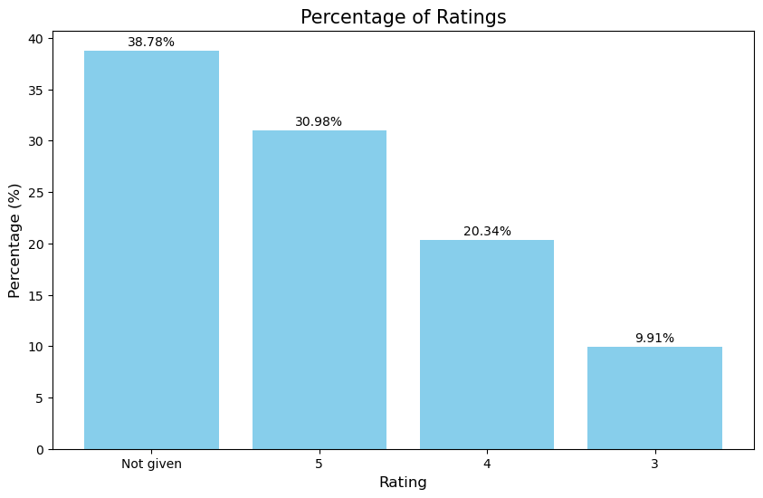

```python
# Plotting the percentage of each rating
plt.figure(figsize=(10, 6))
plt.bar(percentage_with_index['rating'].astype(str), percentage_with_index['Percent'], color='skyblue')

# Adding titles and labels
plt.title('Percentage of Ratings', fontsize=15)
plt.xlabel('Rating', fontsize=12)
plt.ylabel('Percentage (%)', fontsize=12)

# Displaying the percentage on top of each bar
for i in range(len(percentage_with_index)):
    plt.text(percentage_with_index['rating'].astype(str)[i], percentage_with_index['Percent'][i] + 0.5,
             f"{percentage_with_index['Percent'][i]:.2f}%", ha='center', fontsize=10)

# Show plot
plt.show()
```

## Short Summary

##### 38.78% of the all order are not rated. A lot of people are not interested to give rating.

### 3. Exploratory Data Analysis (EDA)

### 3.1 Univariate Analysis

### Explore the variables and provide observations on distributions. (Generally, histograms, boxplots, countplots, etc. are used for univariate exploration.)

#### Order ID

```python
# check unique order ID
df['order_id'].nunique()
```

```
1898
```

```python
# Check unique OrderID
if df['order_id'].nunique() == df.shape[0]:
    print("All the orders are unique")
else:
    print("All the orders are not unique")
```

```
All the orders are unique
```

#### Customer ID

```python
# check unique customer ID
df['customer_id'].nunique()  ## Complete the code to find out number of unique Customer ID
```

```
1200
```

```python
# Check unique Customer
if df['customer_id'].nunique() == df.shape[0]:
    print("All the customers are unique")
else:
    print("All the customers are not unique")
```

```
All the customers are not unique
```

#### Restaurant name

```python
# check unique Restaurant Name
df['restaurant_name'].nunique()  ## Complete the code to find out number of unique Restaurant Name
```

```
178
```

```python
# Check unique Restaurant
if df['restaurant_name'].nunique() == df.shape[0]:
    print("All the restaurants are unique")
else:
    print("All the restaurants are not unique")
```

```
All the restaurants are not unique
```

#### Cuisine type

```python
# Check unique cuisine type
df['cuisine_type'].nunique() ## Complete the code to find out  number of  unique cuisine type
```

```
14
```

```python
# Check unique Cuisine
if df['cuisine_type'].nunique() == df.shape[0]:
    print("All the cuisine_type are unique")
else:
    print("All the cuisine_type are not unique")
```

```
All the cuisine_type are not unique
```

## Short Summary

##### 1. 1898 total orders.

##### 2. 1200 unique customers.

##### 3. Total 178 restaurants.

##### 4. Total 14 types of cuisine.

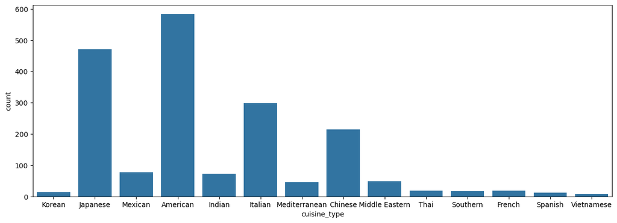

```python
plt.figure(figsize = (15,5))
sns.countplot(data = df, x = 'cuisine_type') ## Create a countplot for cuisine type.
```

```python
# Calculate the count of each category
category_counts = df['cuisine_type'].value_counts()

# Calculate the percentage of each category
category_percentages = (category_counts / category_counts.sum()) * 100

# Convert to DataFrame
category_percentage_df = category_percentages.reset_index()
category_percentage_df.columns = ['Category', 'Percentage']
print(category_percentage_df)
```

```
          Category  Percentage
0         American   30.769231
1         Japanese   24.762908
2          Italian   15.700738
3          Chinese   11.327713
4          Mexican    4.056902
5           Indian    3.846154
6   Middle Eastern    2.581665
7    Mediterranean    2.423604
8             Thai    1.001054
9           French    0.948367
10        Southern    0.895680
11          Korean    0.684932
12         Spanish    0.632244
13      Vietnamese    0.368809
```

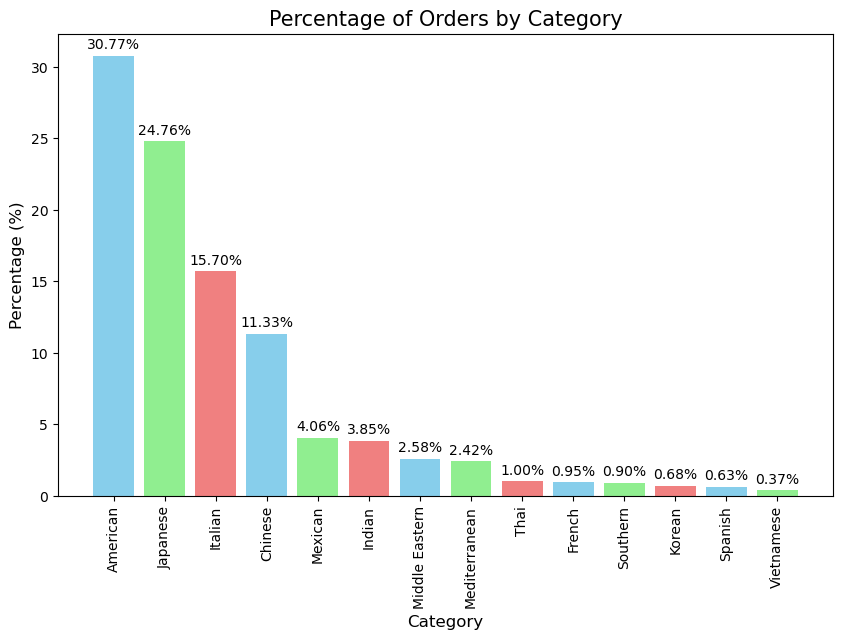

```python
# Plotting the percentage of each rating
plt.figure(figsize=(10, 6))
plt.bar(category_percentage_df['Category'], category_percentage_df['Percentage'], color=['skyblue', 'lightgreen', 'lightcoral'])

# Adding titles and labels
plt.title('Percentage of Orders by Category', fontsize=15)
plt.xlabel('Category', fontsize=12)
plt.ylabel('Percentage (%)', fontsize=12)
plt.xticks(rotation=90)

# Displaying the percentage on top of each bar
for i in range(len(category_percentage_df)):
    plt.text(i, category_percentage_df['Percentage'][i] + 0.5,
             f"{category_percentage_df['Percentage'][i]:.2f}%", ha='center', fontsize=10, color='black')

# Show plot
plt.show()
# Transpose the DataFrame for stacking
```

## Short Summary

##### 1. Among different cuisines american cuisine is the most popular. (30.77%)

##### 2. People also like japanese (24.76%), italian (15.70%) and chinese (11.33%) cuisines.

### Cost of the order

```python
pd.DataFrame(df.cost_of_the_order).value_counts()
```

```
cost_of_the_order
12.18                86
12.13                82
12.23                47
24.20                42
29.10                37
                     ..
13.77                 1
4.66                  1
14.26                 1
14.45                 1
35.41                 1
Name: count, Length: 312, dtype: int64
```

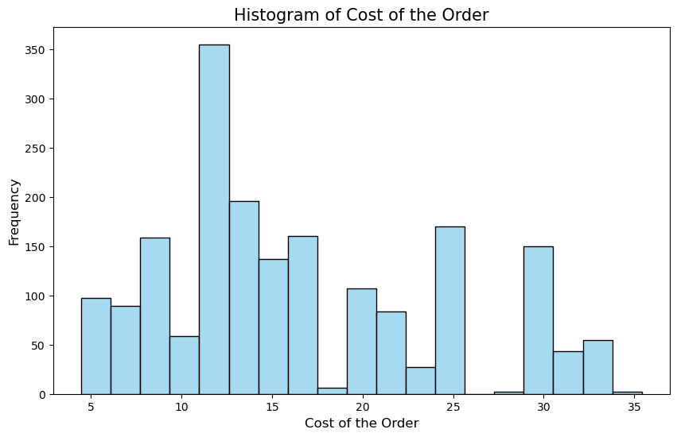

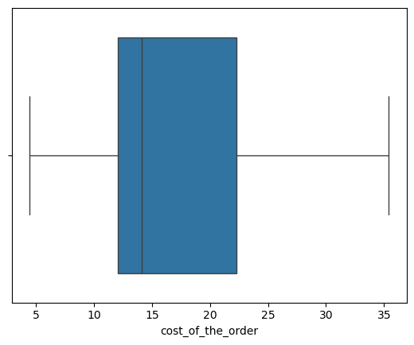

```python
data_range = df['cost_of_the_order'].max() - df['cost_of_the_order'].min()
interval_size = len(df)
bin_size = data_range / interval_size
num_bins = int(data_range / bin_size)

# Plotting the histogram of cost_of_the_order with specified bins
plt.figure(figsize=(10, 6))
sns.histplot(df['cost_of_the_order'], bins='auto', kde=False, color='skyblue')

# Adding titles and labels
plt.title('Histogram of Cost of the Order', fontsize=15)
plt.xlabel('Cost of the Order', fontsize=12)
plt.ylabel('Frequency', fontsize=12)

# Show plot
plt.show()
sns.boxplot(data=df,x='cost_of_the_order') ## Boxplot for the cost of order
plt.show()
```

## Short Summary

##### 1. Most of the orders are around 11 - 13 dollers

#### Day of the week

```python
# # Check the unique values
print(df['day_of_the_week'].nunique())
df['day_of_the_week'].value_counts()
```

```
2
```

```
day_of_the_week
Weekend    1351
Weekday     547
Name: count, dtype: int64
```

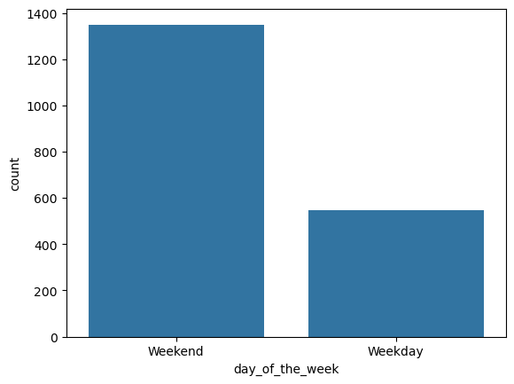

```python
sns.countplot(data = df, x = 'day_of_the_week')
```

## Short Summary

##### 1. People approximately orders twice as much during weekend compared to weekdays.

#### Rating

```python
# Check the unique values
df['rating'].nunique() ## Complete the code to check unique values for the 'rating' column
```

```
4
```

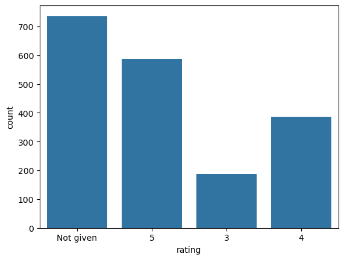

```python
sns.countplot(data = df, x = 'rating') ## Complete the code to plot bar graph for 'rating' column
```

## Short Summary

##### 1. There are 3 types of rating. (5,4,3)

##### 2. There are approximately 39% of the order did not receive any rating)

#### Food Preparation time

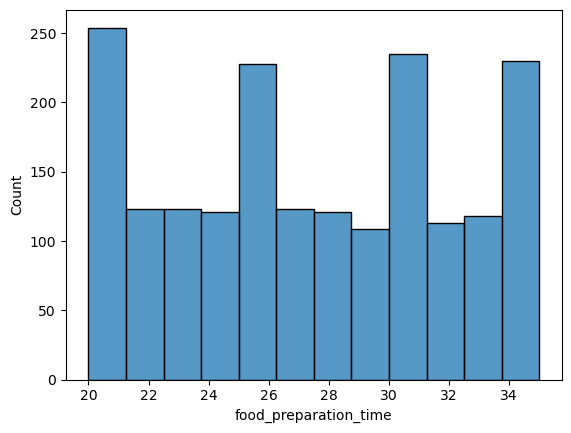

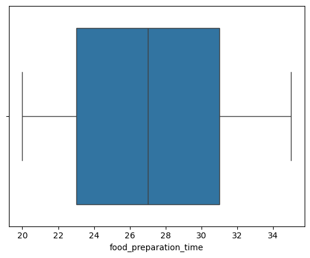

```python
sns.histplot(data=df,x='food_preparation_time') ## Complete the code to plot the histogram for the cost of order
plt.show()
sns.boxplot(data=df,x='food_preparation_time') ## Complete the code to plot the boxplot for the cost of order
plt.show()
```

```python
pd.DataFrame(df.food_preparation_time).value_counts()
# Calculate the count of each category
preparation_time = df['food_preparation_time'].value_counts()

# Calculate the percentage of each category
preparation_time_percent = (preparation_time / preparation_time.sum()) * 100

# Convert to DataFrame
preparation_time_df = preparation_time_percent.reset_index()
preparation_time_df.columns = ['Category', 'Percentage']
print(preparation_time_df)
```

```
    Category  Percentage
0         21    7.112750
1         23    6.480506
2         27    6.480506
3         22    6.480506
4         28    6.375132
5         24    6.375132
6         20    6.269758
7         30    6.269758
8         33    6.217071
9         35    6.164384
10        31    6.111697
11        26    6.059009
12        25    5.953635
13        34    5.953635
14        32    5.953635
15        29    5.742887
```

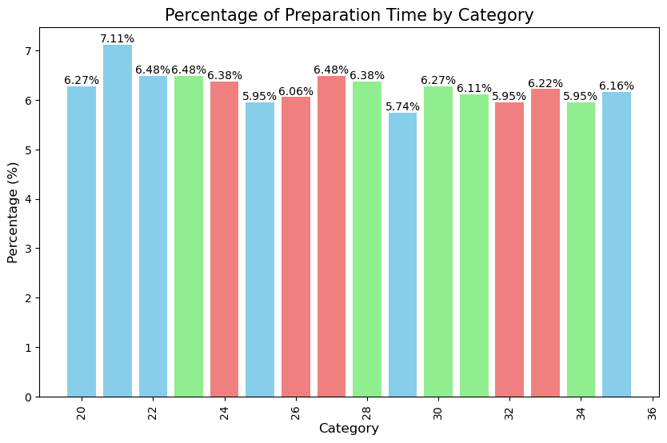

```python
# Plotting the percentage of each preparation time category
plt.figure(figsize=(10, 6))
bars = plt.bar(preparation_time_df['Category'], preparation_time_df['Percentage'], color=['skyblue', 'lightgreen', 'lightcoral'])

# Adding titles and labels
plt.title('Percentage of Preparation Time by Category', fontsize=15)
plt.xlabel('Category', fontsize=12)
plt.ylabel('Percentage (%)', fontsize=12)
plt.xticks(rotation=90)

# Displaying the percentage on top of each bar
for bar in bars:
    height = bar.get_height()
    plt.text(bar.get_x() + bar.get_width() / 2.0, height, f'{height:.2f}%', ha='center', va='bottom', fontsize=10, color='black')

# Show plot
plt.show()
```

## Short Summary

##### 1. Preparation time does not have any impact on placing order.

#### Delivery time

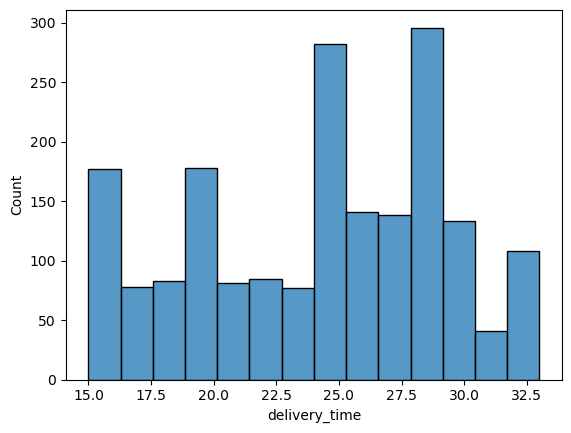

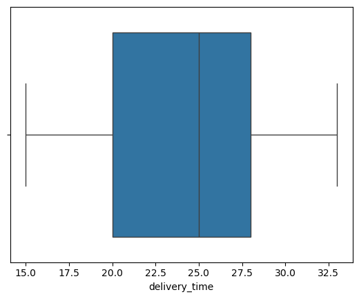

```python
sns.histplot(data=df,x='delivery_time') ## Complete the code to plot the histogram for the delivery time
plt.show()
sns.boxplot(data=df,x='delivery_time') ## Complete the code to plot the boxplot for the delivery time
plt.show()
```

```python
pd.DataFrame(df.delivery_time).value_counts()
# Calculate the count of each category
deli_time = df['delivery_time'].value_counts()

# Calculate the percentage of each category
deli_time_percent = (deli_time / deli_time.sum()) * 100

# Convert to DataFrame
deli_time_df = deli_time_percent.reset_index()
deli_time_df.columns = ['Category', 'Percentage']
# print(deli_time_df)
```

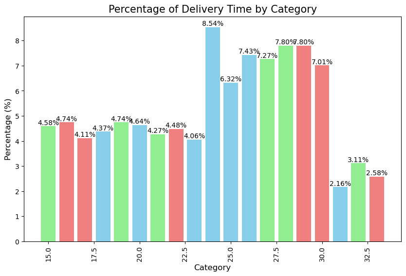

```python
# Plotting the percentage of delivery time category
plt.figure(figsize=(10, 6))
bars = plt.bar(deli_time_df['Category'], deli_time_df['Percentage'], color=['skyblue', 'lightgreen', 'lightcoral'])

# Adding titles and labels
plt.title('Percentage of Delivery Time by Category', fontsize=15)
plt.xlabel('Category', fontsize=12)
plt.ylabel('Percentage (%)', fontsize=12)
plt.xticks(rotation=90)

# Displaying the percentage on top of each bar
for bar in bars:
    height = bar.get_height()
    plt.text(bar.get_x() + bar.get_width() / 2.0, height, f'{height:.2f}%', ha='center', va='bottom', fontsize=10, color='black')

# Show plot
plt.show()
```

## Short Summary

##### 1. Most of the orders took more than 22 minutes to deliver.

### Top 5 restaurants in terms of the number of orders received

```python
# Select the top 5 orders
top_5_restaurant = df['restaurant_name'].value_counts().head(5)
top_5_restaurant
```

```
restaurant_name
Shake Shack                  219
The Meatball Shop            132
Blue Ribbon Sushi            119
Blue Ribbon Fried Chicken     96
Parm                          68
Name: count, dtype: int64
```

```python
df['restaurant_name'].value_counts()
pd.DataFrame(df.restaurant_name).value_counts()
# Calculate the count of each category
restaurant_order = df['restaurant_name'].value_counts().head(15)

# Calculate the percentage of each category
restaurant_order_percent = (restaurant_order / restaurant_order.sum()) * 100

# Convert to DataFrame
restaurant_order_df = restaurant_order_percent.reset_index()
restaurant_order_df.columns = ['Category', 'Percentage']
# print(deli_time_df)
```

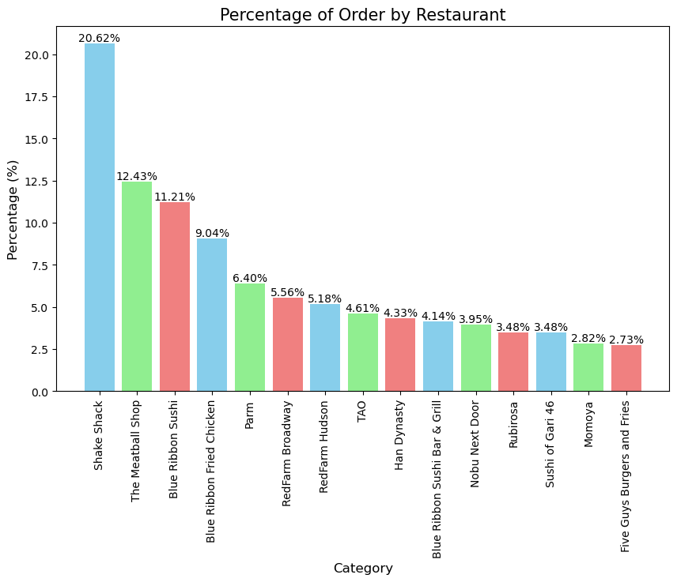

```python
# Plotting the percentage of delivery time category
plt.figure(figsize=(10, 6))
bars = plt.bar(restaurant_order_df['Category'], restaurant_order_df['Percentage'], color=['skyblue', 'lightgreen', 'lightcoral'])

# Adding titles and labels
plt.title('Percentage of Order by Restaurant', fontsize=15)
plt.xlabel('Category', fontsize=12)
plt.ylabel('Percentage (%)', fontsize=12)
plt.xticks(rotation=90)

# Displaying the percentage on top of each bar
for bar in bars:
    height = bar.get_height()
    plt.text(bar.get_x() + bar.get_width() / 2.0, height, f'{height:.2f}%', ha='center', va='bottom', fontsize=10, color='black')

# Show plot
plt.show()
```

## Short Summary

##### 1. Shake shack is the most popular restaurant.

##### 2. In top 5 restaurant, 4 are american.

### Most popular cuisine on weekends and weekdays

```python
# Get most popular cuisine on weekends
print('Most Popular Cuisine on Weekends')
df_weekend = df[df['day_of_the_week'] == 'Weekend']
df_weekend['cuisine_type'].value_counts() ## Complete the code to check unique values for the cuisine type on weekend
```

```
Most Popular Cuisine on Weekends
```

```
cuisine_type
American          415
Japanese          335
Italian           207
Chinese           163
Mexican            53
Indian             49
Mediterranean      32
Middle Eastern     32
Thai               15
French             13
Korean             11
Southern           11
Spanish            11
Vietnamese          4
Name: count, dtype: int64
```

```python
# Get most popular cuisine on weekends
print('Most Popular Cuisine on Weekdays')
df_weekday = df[df['day_of_the_week'] == 'Weekday']
df_weekday['cuisine_type'].value_counts() ## Complete the code to check unique values for the cuisine type on weekend
```

```
Most Popular Cuisine on Weekdays
```

```
cuisine_type
American          169
Japanese          135
Italian            91
Chinese            52
Mexican            24
Indian             24
Middle Eastern     17
Mediterranean      14
Southern            6
French              5
Thai                4
Vietnamese          3
Korean              2
Spanish             1
Name: count, dtype: int64
```

## Short Summary

##### 1. Irrespective of weekend or weekday, american cuisine is the most popular and then japanese, italian and chinese cuisine repsectively.

### Orders cost more than 20 dollars

```python
# Get orders that cost above 20 dollars
df_greater_than_20 = df[df['cost_of_the_order']>20] ## Write the appropriate column name to get the orders having cost above $20

# Calculate the number of total orders where the cost is above 20 dollars
print('Total number of orders:', df['cuisine_type'].value_counts().sum())
print('The number of total orders that cost above 20 dollars is:', df_greater_than_20.shape[0])

# Calculate percentage of such orders in the dataset
percentage = (df_greater_than_20.shape[0] / df.shape[0]) * 100

print("Percentage of orders above 20 dollars:", round(percentage, 2), '%')
```

```
Total number of orders: 1898
The number of total orders that cost above 20 dollars is: 555
Percentage of orders above 20 dollars: 29.24 %
```

### Mean order delivery time

```python
# Get the mean delivery time
mean_del_time = df['delivery_time'].mean()  ## Write the appropriate function to obtain the mean delivery time

print('The maximum delivery time for this dataset is', df['delivery_time'].max(), 'minutes')
print('The minimum delivery time for this dataset is', df['delivery_time'].min(), 'minutes')
print('The mean delivery time for this dataset is', round(mean_del_time, 2), 'minutes')
```

```
The maximum delivery time for this dataset is 33 minutes
The minimum delivery time for this dataset is 15 minutes
The mean delivery time for this dataset is 24.16 minutes
```

### The company has decided to give 20% discount vouchers to the top 3 most frequent customers.

```python
df['customer_id'].value_counts()  ## Write the appropriate column name to get the top 5 cmost frequent customers
```

```
customer_id
52832     13
47440     10
83287      9
250494     8
259341     7
          ..
385426     1
254913     1
289597     1
74412      1
397537     1
Name: count, Length: 1200, dtype: int64
```

```python
# Get the counts of  each customer_id
df['customer_id'].value_counts().head(3)  ## Write the appropriate column name to get the top 5 cmost frequent customers
```

```
customer_id
52832    13
47440    10
83287     9
Name: count, dtype: int64
```

### 3.2 Multivariate Analysis

### Multivariate analysis to explore relationships between the important variables in the dataset.

#### Cuisine vs Cost of the order

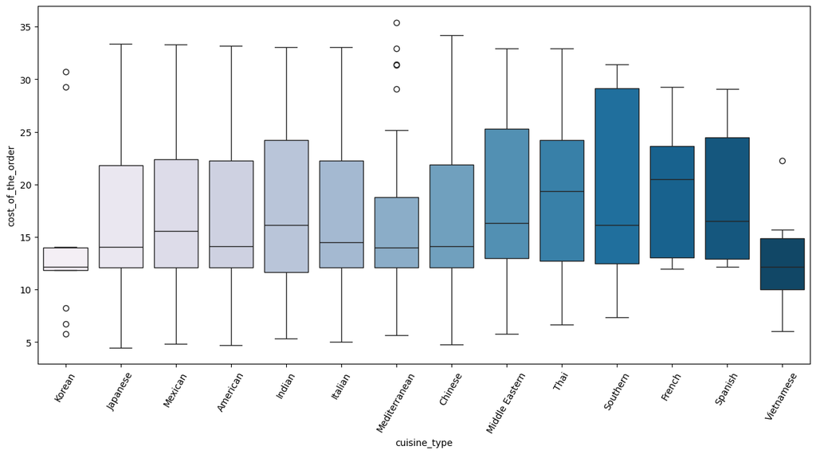

```python
# Relationship between cost of the order and cuisine type
plt.figure(figsize=(15,7))
sns.boxplot(x = "cuisine_type", y = "cost_of_the_order", data = df, palette = 'PuBu', hue = "cuisine_type")
plt.xticks(rotation = 60)
plt.show()
```

#### Cuisine vs Food Preparation time

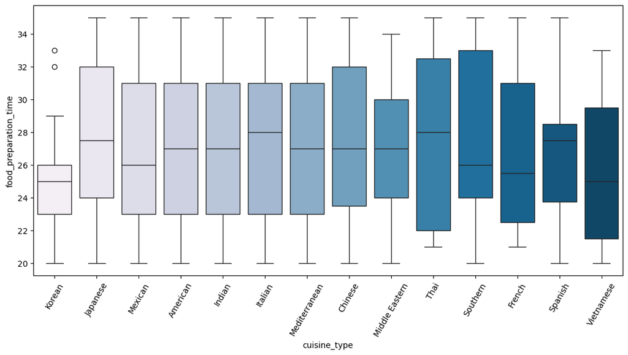

```python
# Relationship between food preparation time and cuisine type
plt.figure(figsize=(13,6))
sns.boxplot(x = "cuisine_type", y = "food_preparation_time", data = df, palette = 'PuBu', hue = "cuisine_type")  ## Complete the code to visualize the relationship between food preparation time and cuisine type using boxplot
plt.xticks(rotation = 60)
plt.show()
```

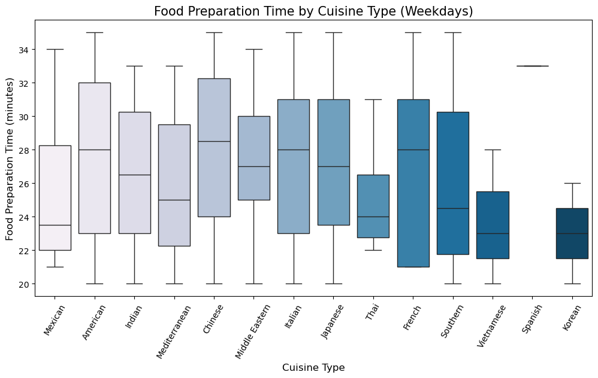

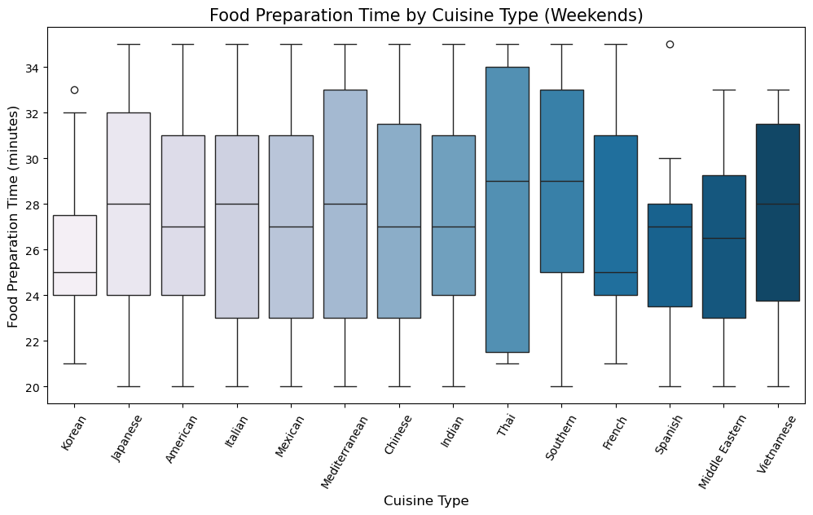

```python
# Filter the DataFrame for weekdays and weekends
weekday_df = df[df['day_of_the_week'] == 'Weekday']
weekend_df = df[df['day_of_the_week'] == 'Weekend']

# Plotting the boxplot for weekdays
plt.figure(figsize=(12, 6))
sns.boxplot(x='cuisine_type', y='food_preparation_time', data=weekday_df, palette='PuBu')
plt.title('Food Preparation Time by Cuisine Type (Weekdays)', fontsize=15)
plt.xticks(rotation = 60)
plt.xlabel('Cuisine Type', fontsize=12)
plt.ylabel('Food Preparation Time (minutes)', fontsize=12)
plt.show()

# Plotting the boxplot for weekends
plt.figure(figsize=(12, 6))
sns.boxplot(x='cuisine_type', y='food_preparation_time', data=weekend_df, palette='PuBu')
plt.title('Food Preparation Time by Cuisine Type (Weekends)', fontsize=15)
plt.xticks(rotation = 60)
plt.xlabel('Cuisine Type', fontsize=12)
plt.ylabel('Food Preparation Time (minutes)', fontsize=12)
plt.show()

# # Relationship between day of the week and delivery time
# plt.figure(figsize=(15,7))
# sns.boxplot(x = "day_of_the_week", y = "delivery_time", data = df, palette = 'PuBu', hue = "cuisine_type")  ## Complete the code to visualize the relationship between day of the week and delivery time using boxplot
# plt.show()
```

## Short Summary

#### Run the below code and write your observations on the revenue generated by the restaurants.

```python
df.groupby(['restaurant_name'])['cost_of_the_order'].sum().sort_values(ascending = False).head(14)
```

```
restaurant_name
Shake Shack                      3579.53
The Meatball Shop                2145.21
Blue Ribbon Sushi                1903.95
Blue Ribbon Fried Chicken        1662.29
Parm                             1112.76
RedFarm Broadway                  965.13
RedFarm Hudson                    921.21
TAO                               834.50
Han Dynasty                       755.29
Blue Ribbon Sushi Bar & Grill     666.62
Rubirosa                          660.45
Sushi of Gari 46                  640.87
Nobu Next Door                    623.67
Five Guys Burgers and Fries       506.47
Name: cost_of_the_order, dtype: float64
```

#### Rating vs Delivery time

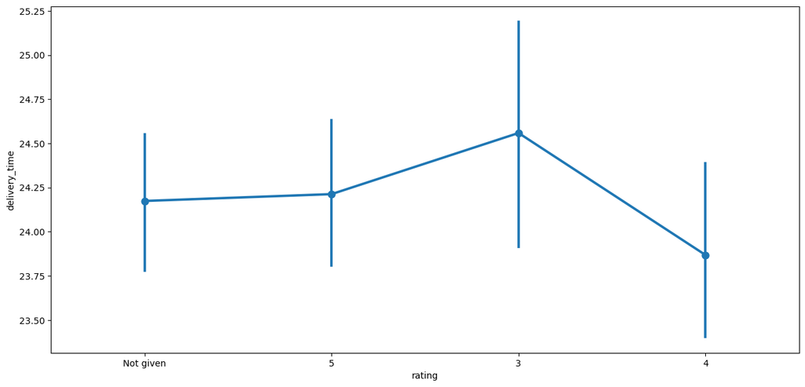

```python
# Relationship between rating and delivery time
plt.figure(figsize=(15, 7))
sns.pointplot(x = 'rating', y = 'delivery_time', data = df)
plt.show()
```

#### Rating vs Food preparation time

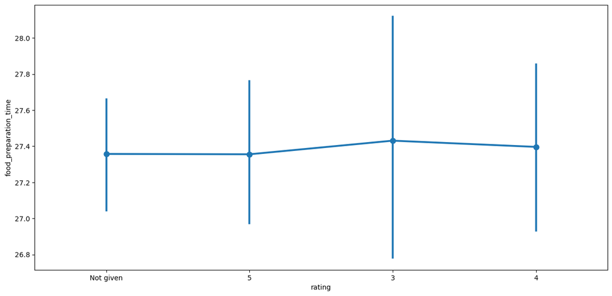

```python
# Relationship between rating and food preparation time
plt.figure(figsize=(15, 7))
sns.pointplot(x = 'rating', y = 'food_preparation_time', data = df)  ## Complete the code to visualize the relationship between rating and food preparation time using pointplot
plt.show()
```

#### Rating vs Cost of the order

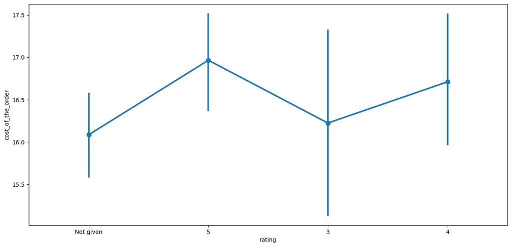

```python
# Relationship between rating and cost of the order
plt.figure(figsize=(15, 7))
sns.pointplot(x = 'rating', y = 'cost_of_the_order', data = df)   ## Complete the code to visualize the relationship between rating and cost of the order using pointplot
plt.show()
```

## Short Summary

##### 2. Preparation Time: Food preparation time remains relatively stable across different ratings, showing minimal variation.

##### 3. Cost of the Order: The cost peaks with a 5-star rating and shows a moderate decrease for 3-star ratings, with noticeable variability across all ratings.

#### Correlation among variables

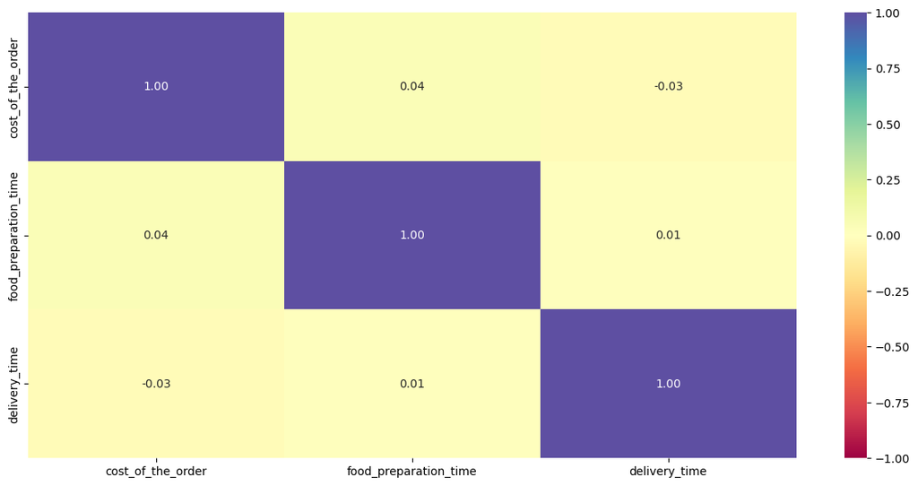

```python
# Plot the heatmap
col_list = ['cost_of_the_order', 'food_preparation_time', 'delivery_time']
plt.figure(figsize=(15, 7))
sns.heatmap(df[col_list].corr(), annot=True, vmin=-1, vmax=1, fmt=".2f", cmap="Spectral")
plt.show()
```

## Short Summary

##### 1. The heatmap shows that cost, preparation time, and delivery time are largely independent factors with minimal correlation

### 4. The company wants to provide a promotional offer in the advertisement of the restaurants. The condition to get the offer is that the restaurants must have a rating count of more than 50 and the average rating should be greater than 4. Find the restaurants fulfilling the criteria to get the promotional offer.

#### Number of Rating

```python
# Filter the rated restaurants
df_rated = df[df['rating'] != 'Not given'].copy()

# Convert rating column from object to integer
df_rated['rating'] = df_rated['rating'].astype('int')

# Create a dataframe that contains the restaurant names with their rating counts
df_rating_count = df_rated.groupby(['restaurant_name'])['rating'].count().sort_values(ascending = False).reset_index()
df_rating_count.head()
```

|  | restaurant_name | rating |
| --- | --- | --- |
| 0 | Shake Shack | 133 |
| 1 | The Meatball Shop | 84 |
| 2 | Blue Ribbon Sushi | 73 |
| 3 | Blue Ribbon Fried Chicken | 64 |
| 4 | RedFarm Broadway | 41 |

#### Average Rating

```python
# Get the restaurant names that have rating count more than 50
rest_names = df_rating_count[df_rating_count['rating'] > 50]['restaurant_name'] ## Complete the code to get the restaurant names having rating count more than 50

# Filter to get the data of restaurants that have rating count more than 50
df_mean_4 = df_rated[df_rated['restaurant_name'].isin(rest_names)].copy()

# Group the restaurant names with their ratings and find the mean rating of each restaurant
df_mean_4.groupby(['restaurant_name'])['rating'].mean().sort_values(ascending = False).reset_index().dropna() ## Complete the code to find the mean rating
```

|  | restaurant_name | rating |
| --- | --- | --- |
| 0 | The Meatball Shop | 4.511905 |
| 1 | Blue Ribbon Fried Chicken | 4.328125 |
| 2 | Shake Shack | 4.278195 |
| 3 | Blue Ribbon Sushi | 4.219178 |

### Short Summary

##### 1. Eligible Restaurants: Shake Shack, The Meatball Shop, Blue Ribbon Sushi, and Blue Ribbon Fried Chicken have rating counts over 50 and average ratings 4 or more.

##### 2. Ineligible Restaurant: RedFarm Broadway does not meet the criteria due to a rating count of 41, which is below the required 50

### 5. The company charges the restaurant 25% on the orders having cost greater than 20 dollars and 15% on the orders having cost greater than 5 dollars. Find the net revenue generated by the company across all orders.

```python
#function to determine the revenue
def compute_rev(x):
    if x > 20:
        return x*0.25
    elif x > 5:
        return x*0.15
    else:
        return x*0

df['Revenue'] = df['cost_of_the_order'].apply(compute_rev) ## Write the apprpriate column name to compute the revenue
# df.head()
```

```python
# get the total revenue and print it
total_rev = df['Revenue'].sum() ## Write the appropriate function to get the total revenue
print('The net revenue is around', round(total_rev, 2), 'dollars')
```

```
The net revenue is around 6166.3 dollars
```

### 6. The company wants to analyze the total time required to deliver the food. What percentage of orders take more than 60 minutes to get delivered from the time the order is placed? (The food has to be prepared and then delivered.)

```python
# Calculate total delivery time and add a new column to the dataframe df to store the total delivery time
df['total_time'] = df['food_preparation_time'] + df['delivery_time']


## Write the code below to find the percentage of orders that have more than 60 minutes of total delivery time (see Question 9 for reference)
df_greater_than_60 = df[df['total_time']>60] ## Write the appropriate column name to get the orders having cost above $20

print('The time of total delivery is above 60:', df_greater_than_60.shape[0])

# Calculate percentage of such orders in the dataset
percentage = (df_greater_than_60.shape[0] / df.shape[0]) * 100

print("Percentage of orders above 60 minutes:", round(percentage, 2), '%')
```

```
The time of total delivery is above 60: 200
Percentage of orders above 60 minutes: 10.54 %
```

### 7. The company wants to analyze the delivery time of the orders on weekdays and weekends. How does the mean delivery time vary during weekdays and weekends?

```python
# Get the mean delivery time on weekdays and print it
print('The mean delivery time on weekdays is around',
      round(df[df['day_of_the_week'] == 'Weekday']['delivery_time'].mean()),
     'minutes')


## Write the code below to get the mean delivery time on weekends and print it

print('The mean delivery time on weekdend is around',
       round(df[df['day_of_the_week'] == 'Weekend']['delivery_time'].mean()),
      'minutes')
```

```
The mean delivery time on weekdays is around 28 minutes
The mean delivery time on weekdend is around 22 minutes
```

### Recommendations:

- Most Effective - Promotions: Offer promotions for mid-priced cuisines like Mexican and Indian; highlight affordable options like Korean and Vietnamese.
- Moderately Effective - Efficiency: Streamline preparation for time-consuming cuisines like Thai; promote quick-prep options during peak hours.
- Effective - Quality Focus: Maintain high quality for top-rated cuisines; use feedback to improve lower-rated ones.
- Less Effective - Marketing: Emphasize consistent pricing and preparation times for Mediterranean and Chinese cuisines; leverage high ratings in promotions.
- Promotional Offers: Focus promotional offers on popular restaurants like Shake Shack, The Meatball Shop, Blue Ribbon Sushi, and Blue Ribbon Fried Chicken to attract more customers.